# RBIF111 - Final Exam

Neshita Kipuw

2024-12-15

```r
# Load necessary packages
library(ggplot2)
library(tidyr)
library(dplyr)
library(stats)
library(DESeq2)
library(reshape2)
library(data.table)
library(tibble)
library(plotly)
library(survival)
```

# 1 Question 1

## 1.1 Logistic regression

### 1.1.1 Input is ER IHC status (categorical variable) and output is the overall survival months (continuous variable)

The (hidden) code below will load the provided clinical data set and the mRNA expression data.

```r
# Load the data sets
clin_data <- read.csv("./TCGA_BRCA_clinical_data.csv")
mrna_data <- read.csv("./TCGA_BRCA_mRNA_expression.csv")
clin_data[1:3, 1:5]
```

```
##     Patient_ID Sample_ID_Tumor Sample_ID_Normal Diagnosis_Age Disease_Stage
## 1 TCGA_A7_A0CE TCGA_A7_A0CE_01  TCGA_A7_A0CE_11            57      Stage II
## 2 TCGA_A7_A0CH TCGA_A7_A0CH_01  TCGA_A7_A0CH_11            79      Stage II
## 3 TCGA_A7_A0D9 TCGA_A7_A0D9_01  TCGA_A7_A0D9_11            37      Stage II
```

```r
mrna_data[1:3, 1:5]
```

```
##       X TCGA_A7_A0CE_01 TCGA_A7_A0CH_01 TCGA_A7_A0D9_01 TCGA_A7_A0DB_01
## 1  A1BG          127.05          217.27             181          790.57
## 2  A1CF            1.00            0.00               0            2.00
## 3 A2BP1            0.00            1.00               0            6.00
```

```r
set.seed(123)
# Get relevant columns & omit NA values
clin_data2 <- clin_data %>%
  select(ER_Status_By_IHC, Overall_Survival_Months) %>%
  na.omit() %>%
  filter(ER_Status_By_IHC != "Indeterminate")

# Make sure ER_Status_By_IHC is a factor
clin_data2$ER_Status_By_IHC <- as.factor(clin_data2$ER_Status_By_IHC)

head(clin_data2)
```

```
##   ER_Status_By_IHC Overall_Survival_Months
## 1         Negative                   35.28
## 2         Positive                   37.42
## 3         Positive                   33.08
## 4         Positive                   20.17
## 5         Positive                   25.13
## 6         Positive                   40.54
```

```r
# Logistic Regression on survival months and ER IHC status
log_reg <- glm(ER_Status_By_IHC ~ Overall_Survival_Months,
                family = binomial(link = "logit"),
                data = clin_data2)
# Get coefficients
summary(log_reg)
```

```
##
## Call:
## glm(formula = ER_Status_By_IHC ~ Overall_Survival_Months, family = binomial(link = "logit"),
##     data = clin_data2)
##
## Coefficients:
##                          Estimate Std. Error z value Pr(>|z|)
## (Intercept)              1.796612   0.547098   3.284  0.00102 **
## Overall_Survival_Months -0.009038   0.008749  -1.033  0.30159
## ---
## Signif. codes:  0 '***' 0.001 '**' 0.01 '*' 0.05 '.' 0.1 ' ' 1
##
## (Dispersion parameter for binomial family taken to be 1)
##
##     Null deviance: 92.777  on 89  degrees of freedom
## Residual deviance: 91.719  on 88  degrees of freedom
## AIC: 95.719
##
## Number of Fisher Scoring iterations: 4
```

```r
# Exponentiate the coefficient to get odds ratio
exp(coefficients(log_reg))
```

```
##             (Intercept) Overall_Survival_Months
##               6.0291843               0.9910027
```

```r
# Get confidence interval
confint(log_reg, level = 0.95)
```

```
##                               2.5 %      97.5 %
## (Intercept)              0.77511748 2.939948528
## Overall_Survival_Months -0.02640229 0.008364256
```

```r
# Exponentiate the CI
exp(confint(log_reg, level = 0.95))
```

```
##                             2.5 %    97.5 %
## (Intercept)             2.1708471 18.914873
## Overall_Survival_Months 0.9739432  1.008399
```

**Discussion**  
The logistic regression coefficients give the change in the log odds of the outcome for a one unit increase in the predictor variable. In the model summary results, a negative coefficient (-0.009) indicates that as the “Overall Survival Months” increases, the odds of ER IHC status being “Positive” decrease slightly, but the relationship is pretty weak since the coefficient is close to zero. Further, the odds ratio = 0.991 implies that for every 1-unit increase in the “Overall Survival Months”, the odds of a positive ER IHC status decrease by (1 - 0.991 =) 0.009. The 95% confidence interval show a very small range for the effect of “Overall Survival Months,” and since the odds ratio is so close to 1 it suggests that the continuous variable does not strongly influence the outcome. Finally, since the p-value = 0.3 (> 0.05), the null hypothesis is not rejected and the observed relationship between “overall Survival Months” and “ER IHC Status” is not statistically significant.

# 2 Question 2

## 2.1 Cox regression model (Survival Analysis)

### 2.1.1 Input is ER IHC status (categorical variable), outputs are the overall survival months (continuous variable) and overall survival status (categorical outcome)

The code below will create a new data frame for analysis by Cox proportional hazard model.

```r
# Get relevant columns & omit NA values
clin_data3 <- clin_data %>%
  select(ER_Status_By_IHC, Overall_Survival_Months, Overall_Survival_Status) %>%
  na.omit() %>%
  filter(ER_Status_By_IHC != "Indeterminate")

# Convert survival status to binary (0 = alive, 1 = dead)
clin_data3$Overall_Survival_Status <- ifelse(clin_data3$Overall_Survival_Status == "1:DECEASED", 1, 0)

# Convert ER IHC status to a factor
clin_data3$ER_Status_By_IHC <- as.factor(clin_data3$ER_Status_By_IHC)

head(clin_data3)
```

```
##   ER_Status_By_IHC Overall_Survival_Months Overall_Survival_Status
## 1         Negative                   35.28                       0
## 2         Positive                   37.42                       0
## 3         Positive                   33.08                       0
## 4         Positive                   20.17                       1
## 5         Positive                   25.13                       0
## 6         Positive                   40.54                       0
```

The code below will first create a “Surv” object within the data frame, consisting of the overall survival months as the time variable and the overall survival outcome as the event. This object represents the survival information. Then the Cox proportional hazard model will be performed using the “Surv” object and the ER IHC status.

```r
set.seed(123)
# Create Surv object for model analysis
clin_data3.Surv <- transform(clin_data3,
                            surv = Surv(
                              time = clin_data3$Overall_Survival_Months,
                              event = clin_data3$Overall_Survival_Status,
                              type = "right"
                            )
)
# show the first 5 observations
clin_data3.Surv$surv[1:5]
```

```
## [1] 35.28+ 37.42+ 33.08+ 20.17  25.13+
```

```r
## Cox proportional hazard model
# use the 'surv' column for the formula, not the whole data frame
cox_reg <- coxph(formula = surv ~ ER_Status_By_IHC, data = clin_data3.Surv)
summary(cox_reg)
```

```
## Call:
## coxph(formula = surv ~ ER_Status_By_IHC, data = clin_data3.Surv)
##
##   n= 90, number of events= 35
##
##                             coef exp(coef) se(coef)    z Pr(>|z|)
## ER_Status_By_IHCPositive 0.03693   1.03762  0.41185 0.09    0.929
##
##                          exp(coef) exp(-coef) lower .95 upper .95
## ER_Status_By_IHCPositive     1.038     0.9637    0.4629     2.326
##
## Concordance= 0.539  (se = 0.033 )
## Likelihood ratio test= 0.01  on 1 df,   p=0.9
## Wald test            = 0.01  on 1 df,   p=0.9
## Score (logrank) test = 0.01  on 1 df,   p=0.9
```

**Discussion**  
The p-value tests the null hypothesis that the coefficient is zero, meaning there is no association between ER IHC status and the outcome (i.e., death). The resulting p-value = 0.929, which is greater than the typical $\alpha$ = 0.05; Therefore, it fails to reject the null hypothesis and there is no significant association between ER IHC status and survival time.  
The calculated lower 95% = 0.463 and the upper 95% = 2.326. The range is quite wide, as it reaches below **1** (which indicates reduced risk) and above **1** (which indicates increased risk) – where **1** indicates no effect. This wide range indicates that there is a lot of uncertainty in the estimate, and suggests that the association between ER IHC status and survival outcome is not statistically significant.  
The resulting coefficient (or log hazard ratio) = 0.0369, which is a positive value and indicates that having *Positive* ER IHC status is associated with an increased risk of survival outcome (i.e., death) compared to the *Negative* status; However, since the value is so close to zero, this suggests that there is no meaningful difference in risk.  
The calculated exponentiated coefficient (or hazard ratio) = 1.0376, implies that *Positive* ER IHC status have 3.76% increased risk of death compared with *Negative* status; However, since the hazard ratio is close to **1** the difference in risk is minimal.

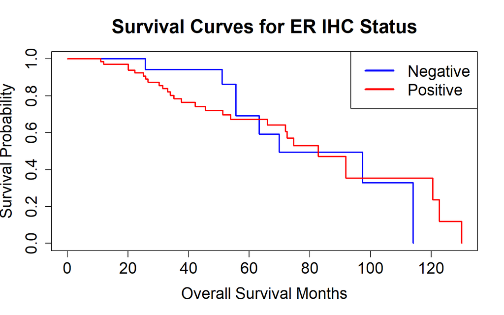

```r
# Fit Kaplan-Meier survival curve
km_fit <- survfit(formula = surv ~ ER_Status_By_IHC, data = clin_data3.Surv)
#summary(km_fit)

# Plot the Kaplan-Meier curve
plot(km_fit, col = c("blue", "red"),
     xlab = "Overall Survival Months",
     ylab = "Survival Probability",
     main = "Survival Curves for ER IHC Status",
     cex.lab = 1.5,
     cex.axis = 1.5,
     cex.main = 1.8,
     lwd = 2)
legend("topright",
       legend = levels(as.factor(clin_data3$ER_Status_By_IHC)),
       col = c("blue", "red"),
       cex = 1.5,
       lwd = 3)
```

# 3 Question 3

## 3.1 Comparison of logistic regression (Q1) and Cox proportional hazard model (Q2)

#### 3.1.0.1 Which model demonstrates higher accuracy?

Both the logistic regression model and the Cox proportional hazard model failed to demonstrate a statistically significant association between the input and output. So I suppose I could argue that both are just as accurate in this case. However, since the context of the analysis is concerned with looking at the amount of time that elapses before an event occurs, the Cox proportional hazard model would be more suitable for survival analysis compared to the logistic regression. Logistic regression ignores the time component and only analyzes a binary outcome. Additionally, the Cox model provides a *concordance index* that is a measure of predictive accuracy, and in this case the result of 0.539 indicates a weak ability (a value of 0.5 equals random guessing). Based on this, I now could argue that the Cox proportional hazard model demonstrates higher accuracy.

#### 3.1.0.2 Why is “Overall_Survival_Status” necessary when “overall survival months” already serves as an output?

In survival analysis, Cox model, both variables are needed. The overall survival months captures when the event happens (i.e., time component), while the overall survival status captures whether the event occurred (i.e., alive or deceased). Without the overall survival status, the model won’t be able to differentiate between subjects who experienced the event/outcome. Furthermore, it would be assumed that all the subjects experienced the event (i.e., death) which can lead to biased results and/or incorrect survival estimates.

# 4 Question 4

## 4.1 Identifying genes most significantly associated with “overall survival months” and “overall survival status” in tumor samples

The code below will first subset the mRNA expression data set to include only the tumor sample IDs and the corresponding gene expressions. Then the median for each gene is calculated and stored in a new column appended in the data set. Finally, a new variable is created to store gene expressions greater-than **1**, which will be used for subsequent analysis. (This is done because having gene expression values as zero creates errors in subsequent codes.)

```r
# Get the tumor data set
tumor_data <- mrna_data[, 1:104]
# rename the first column to gene
colnames(tumor_data)[1] <- "gene"

# Calculate the median for each gene and append as a new column
median_expr <- tumor_data %>%
  rowwise() %>%
  mutate(MedianExpression = median(c_across(starts_with("TCGA")))) %>%
  ungroup()

# Sort data & exclude median expression < 1
tumor_data2 <- median_expr %>%
  arrange(desc(MedianExpression)) %>% # sort in descending order
  filter(MedianExpression >= 1) # exclude median expression < 1
# show the generated data
tumor_data2[1:3, 103:105]
```

```
## # A tibble: 3 × 3
##   TCGA_GI_A2C8_01 TCGA_GI_A2C9_01 MedianExpression
##             <dbl>           <dbl>            <dbl>
## 1         1148218          406717           304444
## 2          404903          258073           295981
## 3          273806          276887           254382
```

The code below will prepare the necessary data from both the clinical and mRNA expression data, and merge them into one data frame. Both *overall survival months* and *overall survival status* along with their corresponding sample IDs from the clinical data are needed together with the expression data.

```r
## Prepare mRNA data
# Transpose the expression data (exclude gene names)
mrna_tumor <- t(tumor_data2[, -c(1, 105)])
colnames(mrna_tumor) <- tumor_data2$gene # assign gene names to columns
mrna_tumor_df <- as.data.frame(mrna_tumor) # convert to data frame
# Add patient IDs & move as the first column
mrna_tumor_df$Sample_ID <- rownames(mrna_tumor_df)
mrna_tumor_df <- mrna_tumor_df %>%
  select(Sample_ID, everything()) # move column for last to first
# show the first row of the first 5 columns
mrna_tumor_df[1:5, 1:5]
```

```
##                       Sample_ID COL1A1    FN1   ACTB COL1A2
## TCGA_A7_A0CE_01 TCGA_A7_A0CE_01  91576 269456 401364  66866
## TCGA_A7_A0CH_01 TCGA_A7_A0CH_01 385065 295981 155586 334316
## TCGA_A7_A0D9_01 TCGA_A7_A0D9_01 256523 310150 207666 195621
## TCGA_A7_A0DB_01 TCGA_A7_A0DB_01 401713 254429 261641 285439
## TCGA_A7_A13E_01 TCGA_A7_A13E_01 154976 186520 186164 106959
```

```r
## Prepare clinical data
# Subset clinical data for tumor samples
clin_data_tumor <- clin_data %>%
  select(Sample_ID = Sample_ID_Tumor,
         survival_time = Overall_Survival_Months,
         survival_status = Overall_Survival_Status) %>%
  na.omit()
# Convert survival status to binary
clin_data_tumor$survival_status <- ifelse(clin_data_tumor$survival_status == "1:DECEASED", 1, 0)

# Merge mRNA and clinical data
merged_data <- merge(clin_data_tumor, mrna_tumor_df, by = "Sample_ID")
# show the first 5 rows & columns of the merged data
merged_data[1:5, 1:5]
```

```
##         Sample_ID survival_time survival_status COL1A1    FN1
## 1 TCGA_A7_A0CE_01         35.28               0  91576 269456
## 2 TCGA_A7_A0CH_01         35.45               0 385065 295981
## 3 TCGA_A7_A0D9_01         37.42               0 256523 310150
## 4 TCGA_A7_A0DB_01         33.08               0 401713 254429
## 5 TCGA_A7_A13E_01         20.17               1 154976 186520
```

The code below will perform the hold-out cross-validation method, using 60% of the data as training set and 40% as the test set. The median expression of each gene will be calculated again (within the code function) to classify the expression as high or low for input into the model. Then, the Cox proportional hazard model will be performed, the p-values will be recorded for each gene, and each p-value will be adjusted with multiple hypothesis testing.

```r
set.seed(123)
# Split data into 60% training and 40% testing
train_idx <- sample(1:nrow(merged_data), 0.6 * nrow(merged_data))
train_data <- merged_data[train_idx, ]
test_data <- merged_data[-train_idx, ]

# Function to perform Cox regression for each gene
cox_analysis <- function(data) {
  genes <- colnames(data)[!(colnames(data) %in% c("Sample_ID", "survival_time", "survival_status"))]
  results <- data.frame(gene=character(), p_value=numeric(), hazard_ratio=numeric())

  for(gene in genes) {
    # calculate median expression for the gene in training data
    median_expr <- median(data[[gene]])

    # create high/low expression groups
    expr_group <- ifelse(data[[gene]] > median_expr, "High", "Low")

    # create Surv object
    surv_obj <- Surv(data$survival_time, data$survival_status)

    # perform cox regression
    cox_model <- tryCatch({
      coxph(surv_obj ~ expr_group)
    }, error = function(e) NULL)

    if(!is.null(cox_model)) {
      summary <- summary(cox_model)
      new_row <- data.frame(
        gene = gene,
        p_value = summary$waldtest["pvalue"],
        hazard_ratio = exp(coef(cox_model)),
        stringsAsFactors = FALSE
      )
      results <- dplyr::bind_rows(results, new_row)
    }
  }
  return(results)
}

# Execute function with training data
train_analysis <- cox_analysis(train_data)
# Adjust p-values for multiple testing
train_analysis$p_adj <- p.adjust(train_analysis$p_value, method = "BH")
# Sort by adjusted p-values and get top 5 genes
train_top5_genes <- train_analysis %>%
  arrange(p_adj) %>%
  head(5)
print(train_top5_genes)
```

```
##               gene     p_value hazard_ratio     p_adj
## pvalue...1 CAPRIN1 0.003809494    0.1631694 0.3124974
## pvalue...2 FAM120A 0.002976780    0.2172917 0.3124974
## pvalue...3   HLA-E 0.003686148    5.0404689 0.3124974
## pvalue...4   LMAN1 0.003635792    0.2205662 0.3124974
## pvalue...5   GFPT1 0.003862694    0.2003289 0.3124974
```

The next code will validate the model on the test data set generated previously. The p-values of the training set’s top 5 genes, resulting from both the training and testing set, will be reported. Finally, the top 5 genes obtained from the testing set will be reported as well.

```r
## Validate on test data
testSet_analysis <- cox_analysis(test_data)
# Adjust p-values for multiple testing
testSet_analysis$p_adj <- p.adjust(testSet_analysis$p_value, method = "BH")

# Compare results between training and test sets for top 5 genes
validation <- testSet_analysis %>%
  filter(gene %in% train_top5_genes$gene) %>%
  arrange(match(gene, train_top5_genes$gene))

print(validation)
```

```
##               gene   p_value hazard_ratio     p_adj
## pvalue...1 CAPRIN1 0.5986364    0.7782482 0.9835893
## pvalue...2 FAM120A 0.3790979    0.6379866 0.9811333
## pvalue...3   HLA-E 0.2512831    0.5367234 0.9811333
## pvalue...4   LMAN1 0.8272517    0.8922128 0.9921298
## pvalue...5   GFPT1 0.5068560    0.7207266 0.9823890
```

```r
# Get top 5 genes from test set
test_top5_genes <- testSet_analysis %>%
  arrange(p_adj) %>%
  head(5)
print(test_top5_genes)
```

```
##              gene   p_value hazard_ratio     p_adj
## pvalue...1 COL1A1 0.2624916    1.7275391 0.9811333
## pvalue...2 EEF1A1 0.2702243    0.5842190 0.9811333
## pvalue...3  ACTG1 0.3214307    0.6033535 0.9811333
## pvalue...4  GAPDH 0.1445023    0.4961836 0.9811333
## pvalue...5  AHNAK 0.1725374    0.5122776 0.9811333
```

The corresponding Kaplan-Meier plots for the top 5 genes resulting from the testing set are displayed below.

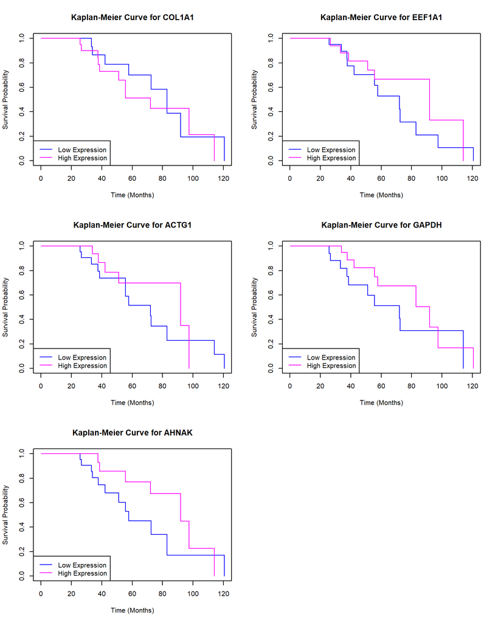

```r
## Plot Kaplan-Meier Curve for testing set's top 5 genes
# Function to plot KM curves
plot_km_curves <- function(test_data, tumor_data2, test_top5_genes) {
  # plot parameters
  par(mfrow = c(3, 2))
  # for loop to plot each gene
  for(gene in test_top5_genes$gene) {
    # make surv object
    surv_obj <- Surv(test_data$survival_time, test_data$survival_status)

    # get median expression
    median_expr <- tumor_data2$MedianExpression[tumor_data2$gene == gene]

    # classify into group based on median
    expr_group <- ifelse(test_data[[gene]] > median_expr, "High", "Low")

    # make KM curve using expression group
    km_curve <- survfit(surv_obj ~ expr_group)

    # plot the KM curve
    plot(km_curve,
         main = paste("Kaplan-Meier Curve for", gene),
         xlab = "Time (Months)",
         ylab = "Survival Probability",
         col = c("blue", "magenta"))

    # add legend
    legend("bottomleft",
           legend = c("Low Expression", "High Expression"),
           col = c("blue", "magenta"),
           lty = 1)
  }

  # Reset plotting parameters
  par(mfrow = c(1, 1))
}

# Execute the function
plot_km_curves(test_data, tumor_data2, test_top5_genes)
```

# 5 Question 5

## 5.1 External validation with outside dataset and comparison with top 5 genes generated previously

The data set obtained from cbioportal.com is part of The Cancer Genome Atlas (TCGA) program which collected clinicopathologic annotation data with multi-platform molecular profiles of >11,000 human tumors of 33 different cancer types. The gene expression data contains 20,531 rows for genes and 1,084 columns for sample IDs.

The code below will load the clinical and mRNA expression data sets into the R environment. The following codes will subset both data sets to clean-up and gather all relevant data for further analysis.

```r
# Load data sets into R environment
brca_clin_data <- read.csv("./brca_tcga_pan_can_atlas_clinical-data.csv")
brca_mrna_data <- read.csv("./brca_tcga_pan_can_atlas_mRNA.csv")
brca_mrna_data <- as.data.frame(brca_mrna_data)

## Prepare clinical data ##
# Subset relevant columns from clinical data
brca_clinical <- brca_clin_data %>%
  select(Sample_ID = Sample_ID,
         survival_time = Overall_Survival_Months,
         survival_status = Overall_Survival_Status)
# Convert survival status to binary
brca_clinical$survival_status <- ifelse(brca_clinical$survival_status == "1:DECEASED", 1, 0)

head(brca_clinical)
```

```
##         Sample_ID survival_time survival_status
## 1 TCGA-3C-AAAU-01     133.05060               0
## 2 TCGA-3C-AALI-01     131.66979               0
## 3 TCGA-3C-AALJ-01      48.45974               0
## 4 TCGA-3C-AALK-01      47.60496               0
## 5 TCGA-4H-AAAK-01      11.44097               0
## 6 TCGA-5L-AAT0-01      48.55837               0
```

```r
## Prepare mRNA expression data ##
# Subset mrna data set: exclude missing values & second column
brca_seq_data <- brca_mrna_data %>%
    select(-c(2)) %>% # exclude second column
    filter(!is.na(Hugo_Symbol)) %>% # exclude rows with missing values
    rename(gene = Hugo_Symbol) # rename the first column to gene

# Calculate median for each gene and append as a new column
median_genes <- brca_seq_data %>%
  rowwise() %>%
  mutate(MedianExpression = median(c_across(starts_with("TCGA")))) %>%
  ungroup()

# Sort data & exclude median expression < 1
brca_seq_data2 <- median_genes %>%
  arrange(desc(MedianExpression)) %>% # sort in descending order
  filter(MedianExpression >= 1) # exclude median expression < 1

# Transpose the expression data (exclude gene names)
mrna_seq <- t(brca_seq_data2[, -c(1, 1084)])
colnames(mrna_seq) <- brca_seq_data2$gene # assign gene names to columns
mrna_seq_df <- as.data.frame(mrna_seq) # convert to data frame

# Add patient IDs & rearrange columns
mrna_seq_df$Sample_ID <- rownames(mrna_seq_df)
# Substitute "." with "-" in Sample_ID
mrna_seq_df$Sample_ID <- gsub("\\.", "-", mrna_seq_df$Sample_ID)
# Remove duplicate columns keeping first replicate
mrna_seq_df <- mrna_seq_df[, !duplicated(colnames(mrna_seq_df))] %>%
  select(Sample_ID, everything())
# show the first 5 row & columns
mrna_seq_df[1:5, 1:5]
```

```
##                       Sample_ID   COL1A1     ACTB   EEF1A1   COL1A2
## TCGA.3C.AAAU.01 TCGA-3C-AAAU-01  55574.2  41867.1  30241.4  34666.8
## TCGA.3C.AALI.01 TCGA-3C-AALI-01 179261.0 107063.0  32369.8  98721.6
## TCGA.3C.AALJ.01 TCGA-3C-AALJ-01 180821.0 110079.0  57191.3  94717.1
## TCGA.3C.AALK.01 TCGA-3C-AALK-01 434557.0  98775.8 101169.0 236808.0
## TCGA.4H.AAAK.01 TCGA-4H-AAAK-01 413984.0  94600.9  89656.2 298457.0
```

```r
## Merge mRNA and clinical data ##
data_merged <- merge(brca_clinical, mrna_seq_df, by = "Sample_ID")
# show the first 5 rows & columns of the merged data
data_merged[1:5, 1:5]
```

```
##         Sample_ID survival_time survival_status   COL1A1     ACTB
## 1 TCGA-3C-AAAU-01     133.05060               0  55574.2  41867.1
## 2 TCGA-3C-AALI-01     131.66979               0 179261.0 107063.0
## 3 TCGA-3C-AALJ-01      48.45974               0 180821.0 110079.0
## 4 TCGA-3C-AALK-01      47.60496               0 434557.0  98775.8
## 5 TCGA-4H-AAAK-01      11.44097               0 413984.0  94600.9
```

The code below will perform Cox proportional hazard model on the entire data, instead of splitting the data into training & testing sets. The median expression of each gene will be calculated again (within the code function) to classify the expression as high or low for input into the model. Then, the Cox proportional hazard model will be performed, the p-values will be recorded for each gene, and each p-value will be adjusted with multiple hypothesis testing.

```r
## Cox Regression ##
set.seed(123)
# Function to perform Cox regression for each gene
cox_analysis2 <- function(data) {
  genes <- colnames(data)[!(colnames(data) %in% c("Sample_ID", "survival_time", "survival_status"))]
  results <- data.frame(gene=character(), p_value=numeric(), hazard_ratio=numeric())

  for(gene in genes) {
    # calculate median expression for the gene in training data
    median_genes <- median(data[[gene]])

    # create high/low expression groups
    expr_group <- ifelse(data[[gene]] > median_genes, "High", "Low")

    # create Surv object
    surv_obj <- Surv(data$survival_time, data$survival_status)

    # perform cox regression
    cox_model <- tryCatch({
      coxph(surv_obj ~ expr_group)
    }, error = function(e) NULL)

    if(!is.null(cox_model)) {
      summary <- summary(cox_model)
      new_row <- data.frame(
        gene = gene,
        p_value = summary$waldtest["pvalue"],
        hazard_ratio = exp(coef(cox_model)),
        stringsAsFactors = FALSE
      )
      results <- dplyr::bind_rows(results, new_row)
    }
  }
  return(results)
}

# Execute the function
brca_analysis <- cox_analysis2(data_merged)
# Adjust p-values for multiple testing
brca_analysis$p_adj <- p.adjust(brca_analysis$p_value, method = "BH")

head(brca_analysis)
```

```
##              gene   p_value hazard_ratio     p_adj
## pvalue...1 COL1A1 0.8502624    0.9694939 0.9668923
## pvalue...2   ACTB 0.2845927    0.8389822 0.7452130
## pvalue...3 EEF1A1 0.6088653    1.0879384 0.8999669
## pvalue...4 COL1A2 0.4026799    0.8716418 0.8171468
## pvalue...5    FN1 0.4301304    0.8789392 0.8319390
## pvalue...6  ACTG1 0.8174211    1.0383667 0.9585619
```

The next code will compare the results of the model on the external data set with the top 5 genes generated from test data set in Question #4. The results of the model from the previous testing set’s top 5 genes, as well as the external data set, will be reported for comparison.

```r
# Compare results of top 5 genes from Q4 with external data
validation2 <- brca_analysis %>%
  filter(gene %in% test_top5_genes$gene) %>%
  arrange(match(gene, test_top5_genes$gene))

print(validation2)
```

```
##              gene   p_value hazard_ratio     p_adj
## pvalue...1 COL1A1 0.8502624    0.9694939 0.9668923
## pvalue...2 EEF1A1 0.6088653    1.0879384 0.8999669
## pvalue...3  ACTG1 0.8174211    1.0383667 0.9585619
## pvalue...4  GAPDH 0.9547228    1.0093490 0.9895623
## pvalue...5  AHNAK 0.7243668    1.0597897 0.9331301
```

```r
print(test_top5_genes)
```

```
##              gene   p_value hazard_ratio     p_adj
## pvalue...1 COL1A1 0.2624916    1.7275391 0.9811333
## pvalue...2 EEF1A1 0.2702243    0.5842190 0.9811333
## pvalue...3  ACTG1 0.3214307    0.6033535 0.9811333
## pvalue...4  GAPDH 0.1445023    0.4961836 0.9811333
## pvalue...5  AHNAK 0.1725374    0.5122776 0.9811333
```

The corresponding Kaplan-Meier plots for the top 5 genes resulting from the external data set are displayed below.

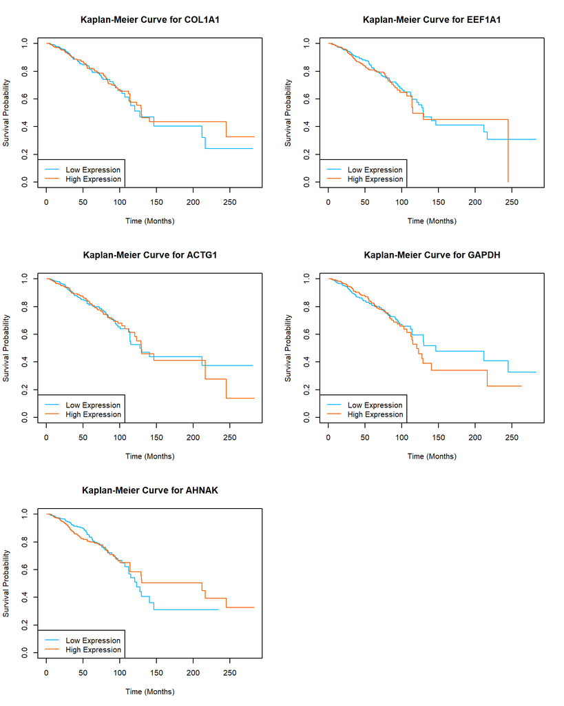

```r
## Plot Kaplan-Meier Curve for top 5 genes using external data results
# Function to plot KM curves
plot_km_curves2 <- function(data_merged, brca_seq_data2, test_top5_genes) {
  # plot parameters
  par(mfrow = c(3, 2))
  # for loop to plot each gene
  for(gene in test_top5_genes$gene) {
    # make surv object
    surv_obj <- Surv(data_merged$survival_time, data_merged$survival_status)

    # get median expression
    median_genes <- brca_seq_data2$MedianExpression[brca_seq_data2$gene == gene]

    # classify into group based on median
    expr_group <- ifelse(data_merged[[gene]] > median_genes, "High", "Low")

    # make KM curve using expression group
    km_curve <- survfit(surv_obj ~ expr_group)

    # plot the KM curve
    plot(km_curve,
         main = paste("Kaplan-Meier Curve for", gene),
         xlab = "Time (Months)",
         ylab = "Survival Probability",
         col = c("#00b7ff", "#ff5e00"))

    # add legend
    legend("bottomleft",
           legend = c("Low Expression", "High Expression"),
           col = c("#00b7ff", "#ff5e00"),
           lty = 1)
  }

  # Reset plotting parameters
  par(mfrow = c(1, 1))
}

# Call the function with your data
plot_km_curves2(data_merged, brca_seq_data2, test_top5_genes)
```